# Python project Mental Health

Maria Brusenina

2023-12-11

# What people are more prone to experience anxiety and depression?

Nowadays, it is well known that mental health issues exist and people all over the world can face anxiety and depression. So it would be interesting to know what groups are more likely to face mental health issues and at what age people are more likely to experience anxiety.

## Description of the database

The dataset was taken from [Wellcome Global Monitor (WGM) 2020 Mental Health Module](https://wellcome.org/reports/wellcome-global-monitor-mental-health/2020) that was indicated as a datasource on the site [Our World in Data: Mental Health](https://ourworldindata.org/mental-health). The original dataset in the ‘full.csv’ file contained 58 columns and 119089 observations. After removing variables not of interest and cleaning, there are left 18 534 rows and 11 columns :

- **COUNTRYNEW** - Country name, there are 107 countries in the dataset
- **Gender** - gender (0 Male, 1 Female)
- **Age** - age of the person
- **Education** - Highest level of educational attainment (1 Elementary or less (8 years or less), 2 Secondary (8-15 years), 3 Tertiary (16+ years))
- **Household_Income** Per Capita Income Quantiles (1 Poorest 20%, 2 Second 20%, 3 Middle 20%, 4 Fourth 20%, 5 Richest 20%)
- **wbi** - Country income level - World Bank most recent definition (0 Low income, 1 Lower-middle income, 2 Upper-middle income, 3 High income)
- **emp** - employment status (0 employed, 1 not employed)
- **age_anx** - age when first felt anxiety
- **close_anx** Friends/Family Have Been Anxious/Depressed (0 Yes, 1 No)
- **felt_anx** Have Felt Anxious/Depressed More Than Once (0 Yes, 1 No)
- **work** Employment status (0 employed, 1 not employed)

## Questions to research:

1. What countries have the lowest and highest mean age of first anxiety?
2. Do men and women experience first anxiety at the same age?
3. What factors (education, employment status, income and having depressed close ones) impact the age of first anxiety ?

## Hypothesis

1. People from countries with higher level of income on average experience first anxiety later than people from countries with low income, because low income countries have more stressful life.
2. The average age of first anxiety is different for men and women, because there exist gender stereotypes regarding expressing emotions.
3. I would assume higher household and country income, employment and not having depressed close ones is correlated with higher age of first anxiety.

## Descriptive analysis

#### Top five coutries by lowest average age of first anxiety.

```
## COUNTRYNEW    wbi
## Myanmar       1      23.525862
## Zambia        1      23.533951
## Turkey        2      23.561905
## Cameroon      1      24.255814
## South Africa  2      24.629213
## Name: age_anx, dtype: float64
```

#### Top five coutries by highest average age of first anxiety.

```
## COUNTRYNEW   wbi
## Kyrgyzstan   1      45.844660
## Kazakhstan   2      42.973684
## Romania      3      38.394558
## South Korea  3      36.616667
## Belgium      3      36.176829
## Name: age_anx, dtype: float64
```

#### Mean age of first anxiety by country’s income level.

```
## wbi
## 3    30.737471
## 2    29.531791
## 0    29.347480
## 1    28.447124
## Name: age_anx, dtype: float64
```

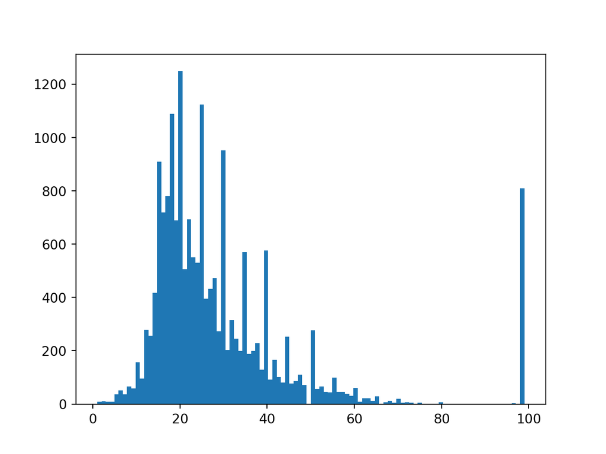

#### For men and women the distribution of age of the first anxiety does not change.

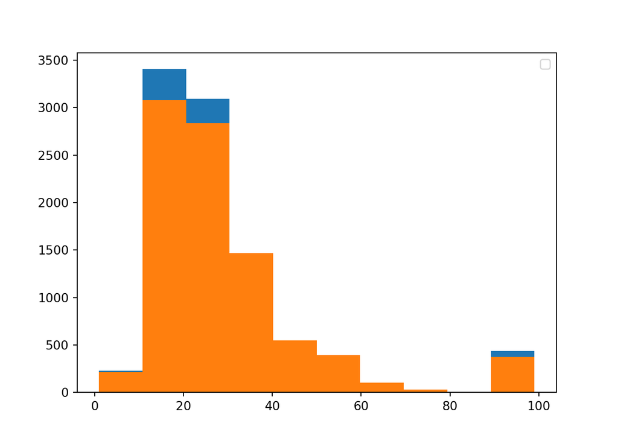

#### There are more people who experienced first axiety at their early 20s among unemployed people than among employed.

**Employed**

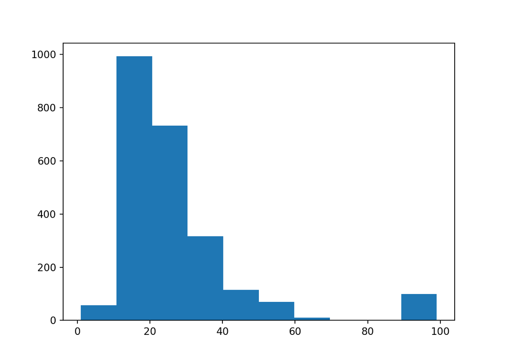

**Not employed**

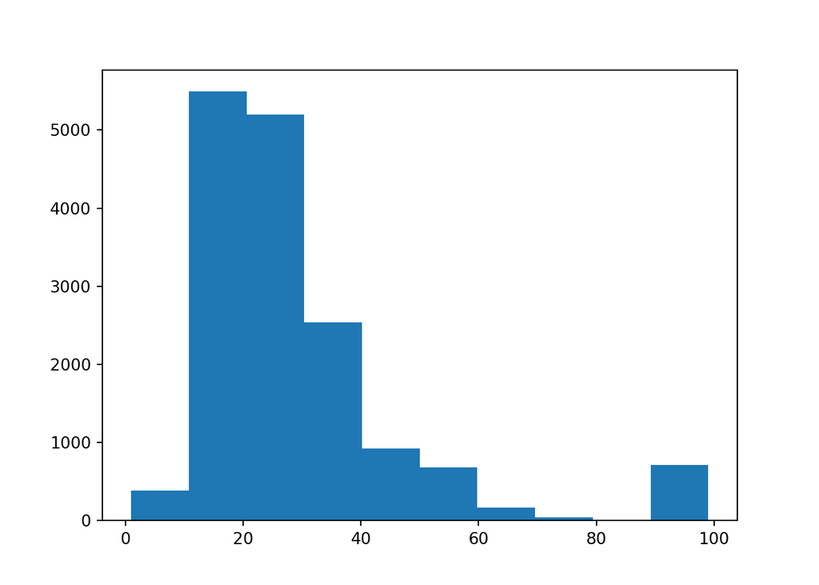

## Is average age of first anxiety the same for men and women?

According to ttest the mean age of first anxiety is different for men and women, but the difference is very small according to Cohen’s d test.

```
## TtestResult(statistic=2.331574962874029, pvalue=0.019733723572011298, df=18532.0)
```

```
## Cohen's d: 0.034266819760974586
```

Average age of first anxiety by gender

```
##           age_anx
## Gender
## 0       29.227881
## 1       29.866534
```

The mean age of first anxiety is a little higher for unemployed than for employed, but still the size effect is rather small.

```
## TtestResult(statistic=-5.0008342709250355, pvalue=6.015112446507144e-07, df=3205.107985299116)
```

```
## Cohen's d: 0.10811036731242188
```

Average age of first anxiety by employment status

```
##        age_anx
## emp
## 0    27.807259
## 1    29.797112
```

## What factors impact the age of first anxiety ?

Linear regression explains not very well the relationships between given variables and the age of the first anxiety. Employment and Gender indeed do not impact the age of first anxiety, whereas higher level of education and not having depressed relatives and friends on average postpones first anxiety for 0,11 and 0,09 year respectively .

```
## const               13.619665
## emp                 -0.083262
## Gender              -0.102849
## Age                  0.543717
## Education            0.110031
## wbi                 -1.990627
## Household_Income    -0.203828
## close_anx            0.093263
## dtype: float64
```

OLS Regression Results

| Dep. Variable: | age_anx | R-squared: | 0.170 |
| --- | --- | --- | --- |
| Model: | OLS | Adj. R-squared: | 0.170 |
| Method: | Least Squares | F-statistic: | 541.7 |
| Date: | Пн, 11 дек 2023 | Prob (F-statistic): | 0.00 |
| Time: | 20:09:42 | Log-Likelihood: | -78793. |
| No. Observations: | 18534 | AIC: | 1.576e+05 |
| Df Residuals: | 18526 | BIC: | 1.577e+05 |
| Df Model: | 7 |  |  |
| Covariance Type: | nonrobust |  |  |

|  | coef | std err | t | P>\|t\| | [0.025 | 0.975] |
| --- | --- | --- | --- | --- | --- | --- |
| const | 13.6197 | 0.550 | 24.754 | 0.000 | 12.541 | 14.698 |
| emp | -0.0833 | 0.381 | -0.219 | 0.827 | -0.830 | 0.663 |
| Gender | -0.1028 | 0.252 | -0.408 | 0.684 | -0.597 | 0.392 |
| Age | 0.5437 | 0.009 | 59.581 | 0.000 | 0.526 | 0.562 |
| Education | 0.1100 | 0.015 | 7.536 | 0.000 | 0.081 | 0.139 |
| wbi | -1.9906 | 0.148 | -13.492 | 0.000 | -2.280 | -1.701 |
| Household_Income | -0.2038 | 0.089 | -2.295 | 0.022 | -0.378 | -0.030 |
| close_anx | 0.0933 | 0.011 | 8.809 | 0.000 | 0.073 | 0.114 |

| Omnibus: | 10508.527 | Durbin-Watson: | 1.905 |
| --- | --- | --- | --- |
| Prob(Omnibus): | 0.000 | Jarque-Bera (JB): | 89047.613 |
| Skew: | 2.655 | Prob(JB): | 0.00 |
| Kurtosis: | 12.333 | Cond. No. | 190. |

Notes:  
[1] Standard Errors assume that the covariance matrix of the errors is correctly specified.